# Mindgames power analysis

2025-01-15

# Simulate data

Here I’ve run a simulated power analysis where we generate data according to certain assumptions about the effects we’re likely to see, how many trials we run, and the variance we expect by ppts and trials. Then we run our planned analysis code on the simulated data and see how often we recover the effects in our statistical tests.

You can see the code to generate results below:

```r
simulate_mindgames <- function(
    n_participants = 100,     # Number of human participants
    trials_per_human = 5,     # Number of trials each human participant completes

    # Base success rates for different conditions
    base_human_success_rate = 0.4,    # Base success rate for humans
    base_llm_success_rate = 0.1,      # Base success rate for LLMs
    reveal_boost_human = 0.15,        # How much reveal condition improves performance for humans
    reveal_boost_llm = 0.25,          # How much reveal condition improves performance for llms

    # Random effects parameters
    participant_sd = 0.5,    # Standard deviation for random participant effects
    trial_sd = 0.1         # Standard deviation for random trial effects
) {

  # Just make the number of LLM trials equal the number of human trials
  n_llm_trials = n_participants * trials_per_human

  # Generate random participant effects and assign conditions between participants
  participants <- tibble(
    participant_id = 1:n_participants,
    participant_effect = rnorm(n_participants, 0, participant_sd),
    # Assign mental_state between participants
    mental_state = sample(
      rep(c("reveal", "no_reveal"), length.out = n_participants),
      n_participants
    )
  )

  # Generate human data
  human_data <- expand_grid(
    participant_id = 1:n_participants,
    trial_num = 1:trials_per_human
  ) %>%
    # Join participant random effects and condition
    left_join(participants, by = "participant_id") %>%
    # Add trial-level random effects
    group_by(participant_id) %>%
    mutate(
      trial_effect = rnorm(trials_per_human, 0, trial_sd)
    ) %>%
    ungroup() %>%
    # Calculate success probability
    mutate(
      base_prob = base_human_success_rate,
      reveal_effect = if_else(mental_state == "reveal", reveal_boost_human, 0),
      success_prob = plogis(qlogis(base_prob) +
                              participant_effect +
                              trial_effect) +
                              reveal_effect,
      # Generate outcomes
      success = rbinom(n(), 1, success_prob),
      persuader_type = "human"
    )


  # Generate LLM data
  llm_data <- tibble(
    trial_num = 1:n_llm_trials,
    mental_state = rep(c("reveal", "no_reveal"), length.out = n_llm_trials),
    trial_effect = rnorm(n_llm_trials, 0, trial_sd)
  ) %>%
    # Calculate success probability
    mutate(
      base_prob = base_llm_success_rate,
      reveal_effect = if_else(mental_state == "reveal", reveal_boost_llm, 0),
      success_prob = plogis(qlogis(base_prob) +
                              trial_effect) +
                              reveal_effect,
      # Generate outcomes
      success = rbinom(n(), 1, success_prob),
      persuader_type = "llm",
      participant_id = 0
    )

  # Combine and clean datasets
  combined_data <- bind_rows(
    human_data %>%
      select(persuader_type, mental_state, participant_id, trial_num, success),
    llm_data %>%
      select(persuader_type, mental_state, trial_num, success)
  ) %>%
    mutate(
      persuader_type = as.factor(persuader_type),
      mental_state = as.factor(mental_state)
    )

  return(combined_data)
}
```

All of these analyses are based on assumptions about variance by ppt and trial, which are not necessarily justifiable, so just a rough guide.

I’ve tested that we can run all of these with mixed effects models, but haven’t used them for the power analysis as it’s challenging to simulate data so that it meets all the assumptions and the model converges nicely. In general, I don’t think we should expect to need more data for the MEMs, and I often do power analysis with simple linear models for this reason. So essentially I think we can use these estimates and still plan to run the mixed effects models in our actual analysis.

Let me know if you see any issues with how I’ve set this up!

Here’s an example of how the data looks with the default params:

```r
example_data <- simulate_mindgames()
head(example_data)
```

```
## # A tibble: 6 × 5
##   persuader_type mental_state participant_id trial_num success
##   <fct>          <fct>                 <int>     <int>   <int>
## 1 human          no_reveal                 1         1       1
## 2 human          no_reveal                 1         2       1
## 3 human          no_reveal                 1         3       0
## 4 human          no_reveal                 1         4       1
## 5 human          no_reveal                 1         5       1
## 6 human          no_reveal                 2         1       1
```

```r
summary(example_data)
```

```
##  persuader_type    mental_state participant_id     trial_num
##  human:500      no_reveal:500   Min.   :  1.00   Min.   :  1.0
##  llm  :500      reveal   :500   1st Qu.: 25.75   1st Qu.:  3.0
##                                 Median : 50.50   Median :  5.0
##                                 Mean   : 50.50   Mean   :126.8
##                                 3rd Qu.: 75.25   3rd Qu.:250.2
##                                 Max.   :100.00   Max.   :500.0
##                                 NA's   :500
##     success
##  Min.   :0.000
##  1st Qu.:0.000
##  Median :0.000
##  Mean   :0.379
##  3rd Qu.:1.000
##  Max.   :1.000
##
```

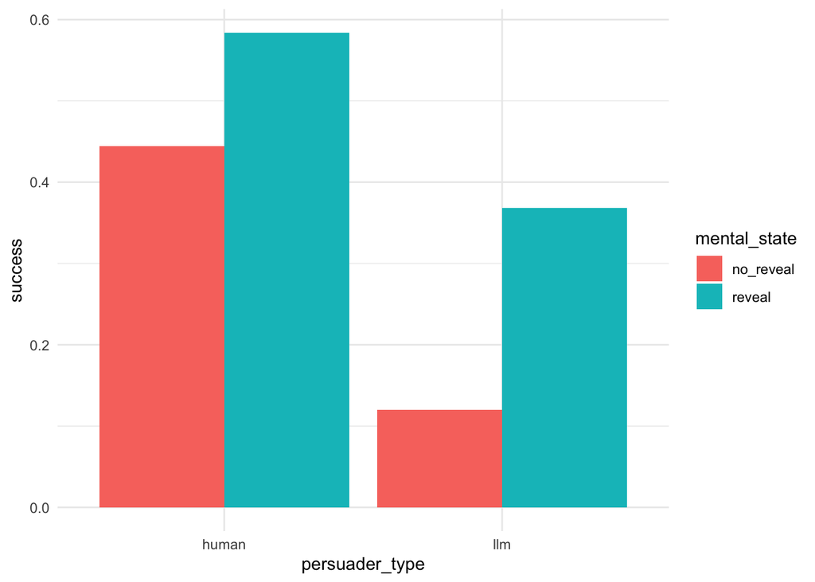

```r
example_data %>%
  ggplot(aes(x = persuader_type, y = success, fill = mental_state)) +
  stat_summary(geom = "bar", fun = "mean", position = position_dodge()) +
    theme_minimal()
```

# H1

For H1 we’re using a logistic regression to ask “Is the human success rate in the no_reveal condition significantly greater than 0.1”?

Why are we using a baseline of 0.1? Essentially we want to check whether performance is above chance. It’s not clear what chance performance would mean on this task. AFAIU, in critical trials, if the ppt does nothing, or types randomly, they will lose. So chance could maybe be 0? But it’s hard to test whether something is significantly different from 0 so we use a small constant instead (a success rate of 10%). There are arguments for making this higher or lower but I think it’s reasonable.

## Example

Here’s how this looks with the example data above:

```r
chance_prob <- 0.1
chance_logodds <- qlogis(chance_prob)

model_data <- example_data %>%
  filter(persuader_type == "human",
         mental_state == "no_reveal") %>%
  # Add offset column
  mutate(offset_term = chance_logodds)

model <- glm(success ~ offset(offset_term) + 1,
               family = binomial,
               data = model_data)

summary(model)
```

```
##
## Call:
## glm(formula = success ~ offset(offset_term) + 1, family = binomial,
##     data = model_data)
##
## Deviance Residuals:
##    Min      1Q  Median      3Q     Max
## -1.083  -1.083  -1.083   1.274   1.274
##
## Coefficients:
##             Estimate Std. Error z value Pr(>|z|)
## (Intercept)   1.9723     0.1273   15.49   <2e-16 ***
## ---
## Signif. codes:  0 '***' 0.001 '**' 0.01 '*' 0.05 '.' 0.1 ' ' 1
##
## (Dispersion parameter for binomial family taken to be 1)
##
##     Null deviance: 343.43  on 249  degrees of freedom
## Residual deviance: 343.43  on 249  degrees of freedom
## AIC: 345.43
##
## Number of Fisher Scoring iterations: 3
```

The intercept is significantly different from our baseline (the units here are in logits, a transformation of probability space which allow you to use linear regressions. lmk if you’re confused about this and want to understand more).

## Power analysis

Now we generate data under different assumptions, varying the no_reveal success rate and the number of participants. The no_ppts here is the total number of human ppts. So only half of these are actually involved in the test (as the other half are in the reveal condition).

It looks like we’re not going to get sufficient power to detect an effect of 0.15 vs 0.1 (which tbh I think is also theoretically good, that’s too small of a difference to care about). For a true SR of 0.2 (a difference of 0.1 from the baseline) we hit 80% power (we detect the effect in 80% of simulations) at 30 total ppts (so only 15 in the no_reveal cond).

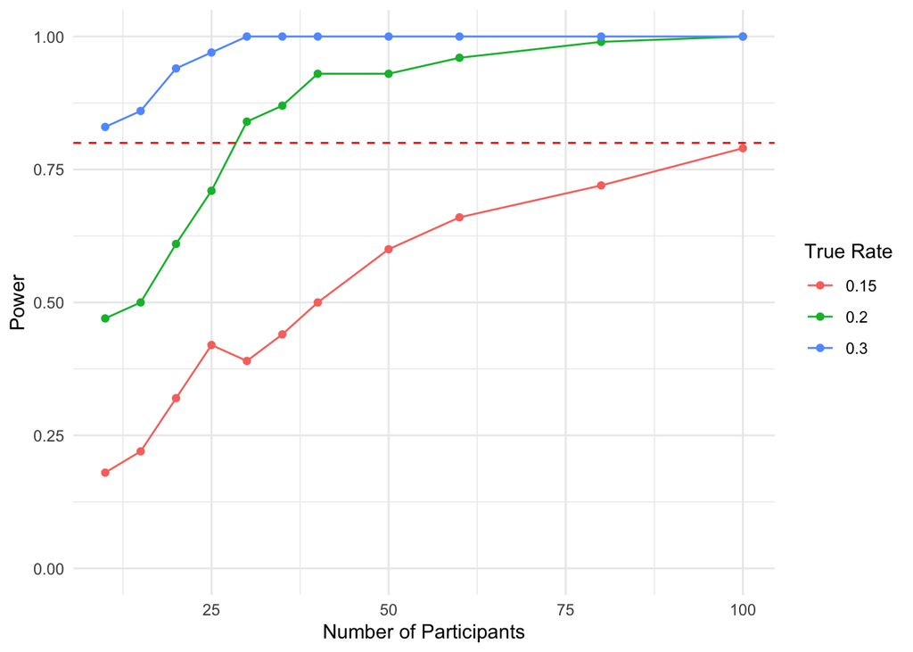

```r
test_h1 <- function(data, chance_prob = 0.1) {  # default to 10% chance success
  # Convert chance probability to log odds for offset
  chance_logodds <- qlogis(chance_prob)

  # Filter for human, no_reveal condition
  model_data <- data %>%
    filter(persuader_type == "human",
           mental_state == "no_reveal") %>%
    # Add offset column
    mutate(offset_term = chance_logodds)

  # Mixed effects Model
  # model <- glmer(success ~ offset(offset_term) + 1 + (1|participant_id),
  #                family = binomial,
  #                data = model_data)

  # Plain logistic regression
  model <- glm(success ~ offset(offset_term) + 1,
                 family = binomial,
                 data = model_data)


  # Extract fixed effect coefficient and p-value
  coef <- summary(model)$coefficients[1, "Estimate"]
  p_value <- summary(model)$coefficients[1, "Pr(>|z|)"]

  return(list(
    estimate = plogis(coef + chance_logodds),  # Convert to probability
    p_value = p_value,
    above_chance = coef > 0  # Is performance above chance level?
  ))
}

power_analysis_h1 <- function(
    n_sims = 100,
    true_rates = c(0.15, 0.2, 0.3),
    n_ppts = c(10, 15, 20, 25, 30, 35, 40, 50, 60, 80, 100)
) {
  # Create results grid
  results <- expand_grid(
    true_rate = true_rates,
    n_ppts = n_ppts
  ) %>%
    group_by(true_rate, n_ppts) %>%
    summarise(
      power = mean(replicate(n_sims, {
        data <- simulate_mindgames(
          n_participants = n_ppts,
          base_human_success_rate = true_rate,
          participant_sd = 0.5
        )
        test_h1(data)$p_value < 0.05
      })),
      .groups = 'drop'
    )

  # Plot
  ggplot(results, aes(x = n_ppts, y = power, color = factor(true_rate))) +
    geom_line() +
    geom_point() +
    geom_hline(yintercept = 0.8, linetype = "dashed", color = "red") +
    scale_y_continuous(limits = c(0, 1)) +
    labs(x = "Number of Participants",
         y = "Power",
         color = "True Rate") +
    theme_minimal()
}

power_analysis_h1()
```

# H2

## Example

For H2 we’re asking “do human ppts perform significantly better in reveal vs no_reveal”. Here’s how the model looks with our example data:

```r
model_data <- example_data %>%
  filter(persuader_type == "human")

model <- glm(success ~ mental_state,
             family = binomial,
             data = model_data)

summary(model)
```

```
##
## Call:
## glm(formula = success ~ mental_state, family = binomial, data = model_data)
##
## Deviance Residuals:
##    Min      1Q  Median      3Q     Max
## -1.324  -1.083   1.037   1.037   1.274
##
## Coefficients:
##                    Estimate Std. Error z value Pr(>|z|)
## (Intercept)         -0.2249     0.1273  -1.767   0.0772 .
## mental_statereveal   0.5642     0.1807   3.121   0.0018 **
## ---
## Signif. codes:  0 '***' 0.001 '**' 0.01 '*' 0.05 '.' 0.1 ' ' 1
##
## (Dispersion parameter for binomial family taken to be 1)
##
##     Null deviance: 692.76  on 499  degrees of freedom
## Residual deviance: 682.92  on 498  degrees of freedom
## AIC: 686.92
##
## Number of Fisher Scoring iterations: 4
```

## Power Analysis

Here we use all the human ppts, set the expected no_reveal SR at 0.1 and how many participants we need to detect different sizes of “reveal effect” (the difference in success rate between reveal and no_reveal). Reveal effects of either 0.05 or 0.1 are probably not detectable with < 100 ppts. But for 0.15 we hit 80% power at around 40-50 total participants.

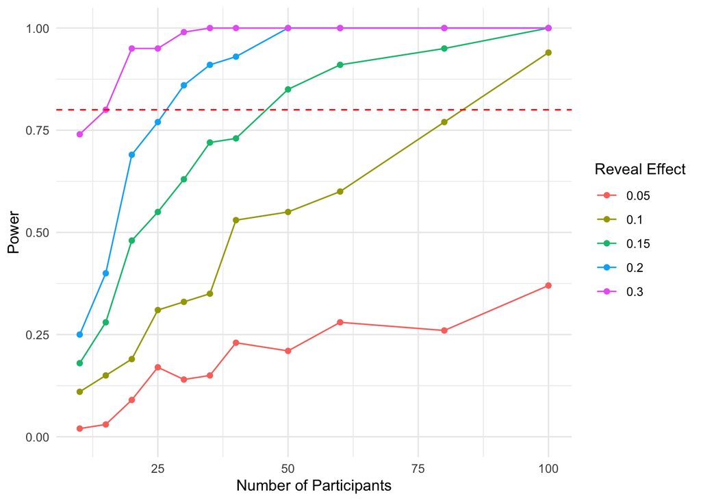

```r
test_h2 <- function(data) {
  # Filter for human data only
  model_data <- data %>%
    filter(persuader_type == "human")

  # Fit model testing reveal effect
  # model <- glmer(success ~ mental_state + (1|participant_id),
  #                family = binomial,
  #                data = model_data)

  model <- glm(success ~ mental_state,
               family = binomial,
               data = model_data)

  # Extract reveal coefficient and p-value
  coef <- summary(model)$coefficients[2, 1]
  p_value <- summary(model)$coefficients["mental_statereveal", "Pr(>|z|)"]

  return(list(
    estimate = plogis(coef),  # Convert to probability scale
    p_value = p_value,
    positive_effect = coef > 0
  ))
}

power_analysis_h2 <- function(
    n_sims = 100,
    reveal_effects = c(0.05, 0.1, 0.15, 0.2, 0.3),  # Difference between conditions
    n_ppts = c(10, 15, 20, 25, 30, 35, 40, 50, 60, 80, 100)
) {
  # Create results grid
  results <- expand_grid(
    reveal_effect = reveal_effects,
    n_ppts = n_ppts
  ) %>%
    group_by(reveal_effect, n_ppts) %>%
    summarise(
      power = mean(replicate(n_sims, {
        data <- simulate_mindgames(
          n_participants = n_ppts,
          base_human_success_rate = 0.1,
          reveal_boost_human = reveal_effect
        )
        test_h2(data)$p_value < 0.05
      })),
      .groups = 'drop'
    )

  # Plot
  ggplot(results, aes(x = n_ppts, y = power, color = factor(reveal_effect))) +
    geom_line() +
    geom_point() +
    geom_hline(yintercept = 0.8, linetype = "dashed", color = "red") +
    scale_y_continuous(limits = c(0, 1)) +
    labs(x = "Number of Participants",
         y = "Power",
         color = "Reveal Effect") +
    theme_minimal()
}

power_analysis_h2()
```

# H3-5

I haven’t simulated H3 & H4. If we use the same number of LLM trials as we do human trials, they should come out statistically very similar. So, say, if we have 50 ppts * 5 trials, we want 250 o1 trials (and I guess the same for the other models).

H5 is conceptually the same as H2 and H4 (logistic regression with a categorical predictor) but we’ll have 2x as much data (human and llm data) so I also haven’t simulated that specifically (assuming it will be less data hungry than H2 or H4).

# H6

I’ve done H6 because it’s more complicated and involves an interaction. The key effect we care about is mental_state:persuader_type (i.e. is the effect of mental_state greater for llms than for humans?).

## Example

We see significant main effects of reveal (increases success) and persuader type (llms are worse). Plus we see a positive interaction of reveal:llm (reveal has a bigger positive effect for llms than humans).

```r
model <- glm(success ~ mental_state * persuader_type,
             family = binomial,
             data = example_data)

summary(model)
```

```
##
## Call:
## glm(formula = success ~ mental_state * persuader_type, family = binomial,
##     data = example_data)
##
## Deviance Residuals:
##     Min       1Q   Median       3Q      Max
## -1.3244  -0.9580  -0.5056   1.0372   2.0593
##
## Coefficients:
##                                      Estimate Std. Error z value Pr(>|z|)
## (Intercept)                           -0.2249     0.1273  -1.767  0.07720 .
## mental_statereveal                     0.5642     0.1807   3.121  0.00180 **
## persuader_typellm                     -1.7675     0.2326  -7.600 2.95e-14 ***
## mental_statereveal:persuader_typellm   0.8875     0.2962   2.996  0.00274 **
## ---
## Signif. codes:  0 '***' 0.001 '**' 0.01 '*' 0.05 '.' 0.1 ' ' 1
##
## (Dispersion parameter for binomial family taken to be 1)
##
##     Null deviance: 1327.1  on 999  degrees of freedom
## Residual deviance: 1195.3  on 996  degrees of freedom
## AIC: 1203.3
##
## Number of Fisher Scoring iterations: 4
```

## Power analysis

Here, I’ve assumed the human no_reveal success rate is 0.4 and the human reveal success rate is 0.5 (a reveal effect of 0.1). I’ve assumed the llm no_reveal rate is 0.1 and varied the llm success rate in the reveal condition.

The plot shows the human:reveal interaction effect (i.e. how much greater is success rate in the reveal condition minus the no_reveal condition for llms vs humans).

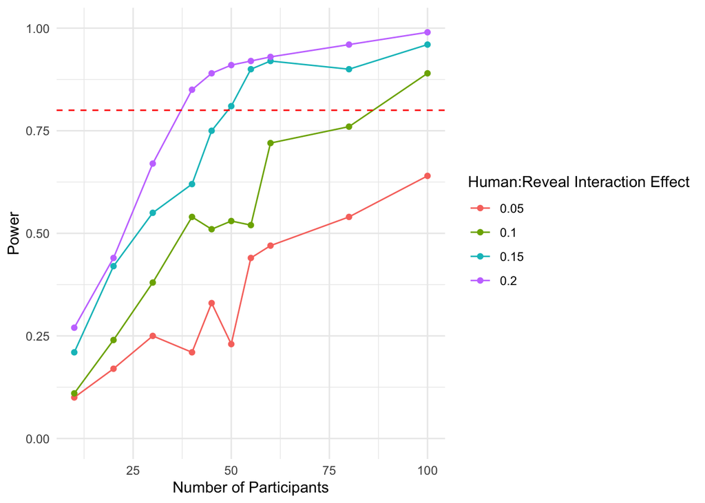

```r
test_h6 <- function(data) {
  # Filter for human data only
  model_data <- data

  # Fit model testing reveal effect
  # model <- glmer(success ~ mental_state + (1|participant_id),
  #                family = binomial,
  #                data = model_data)
  model <- glm(success ~ mental_state * persuader_type,
               family = binomial,
               data = model_data)

  # Extract reveal coefficient and p-value
  coef <- summary(model)$coefficients[4, 1]
  p_value <- summary(model)$coefficients[4, "Pr(>|z|)"]

  return(list(
    estimate = plogis(coef),  # Convert to probability scale
    p_value = p_value,
    positive_effect = coef > 0
  ))
}

power_analysis_h6 <- function(
    n_sims = 100,
    base_human_success_rate = 0.4,
    base_llm_success_rate = 0.1,
    reveal_boost_human = 0.1,
    reveal_boost_llm = c(0.15, 0.2, 0.25, 0.3),
    n_ppts = c(10, 20, 30, 40, 45, 50, 55, 60, 80, 100)
) {
  # Create results grid
  results <- expand_grid(
    reveal_boost_llm = reveal_boost_llm,
    n_ppts = n_ppts
  ) %>%
    group_by(reveal_boost_llm, n_ppts) %>%
    summarise(
      power = mean(replicate(n_sims, {
        data <- simulate_mindgames(
          n_participants = n_ppts,
          base_llm_success_rate = base_llm_success_rate,
          base_human_success_rate = base_human_success_rate,
          reveal_boost_llm = reveal_boost_llm,
          reveal_boost_human = reveal_boost_human
        )
        test_h6(data)$p_value < 0.05
      })),
      .groups = 'drop'
    )

  results <- results %>%
    mutate(
      llm_reveal_ixn = reveal_boost_llm - reveal_boost_human
    )
  # Plot
  ggplot(results, aes(x = n_ppts, y = power, color = factor(llm_reveal_ixn))) +
    geom_line() +
    geom_point() +
    geom_hline(yintercept = 0.8, linetype = "dashed", color = "red") +
    scale_y_continuous(limits = c(0, 1)) +
    labs(x = "Number of Participants",
         y = "Power",
         color = "Human:Reveal Interaction Effect") +
    theme_minimal()
}

power_analysis_h6()
```

# Conclusion

Overall I think this suggests that 50 total (25 per condition) is a reasonable minimum number, and something slightly above that would be safer/more conservative.

All of these assume 5 critical trials per participant and we’d have to increase n if we want to do fewer than that. We should also assume some loss of data (e.g. from ppts not completing the expt) which might lead us toward 70 or 80 rather than 50 or 60.

What do you think?